[figure not shown]

# TP2: Apprentissage Artificiel avec Numpy, Pandas et Scikit-Learn

# Table of contents

1. Descente de gradient
2. Selection de modèles
3. Classement : régression logistique
4. Classfification

## Exercice 1: Descente de gradient

```python
from numpy import *
import matplotlib.pyplot as plt
%matplotlib inline
```

### 1. Rappeler la fonction coût du modèle de régression linéaire h (x).

La fonction coût la plus courante pour un modèle de regression linéaire est la racine carrée de l’erreur quadratique moyenne (Root Squared Error ou RMSE) définie par:

[figure not shown]

### 2. Rappeler les étapes de l’algorithme de descente de gradient.

Le vecteur gradient est donnée par:

[figure not shown]

**Étape 1: Calcul de la dérivée de la Fonction Coût**  
On part d’un point initial aléatoire puis on mesure la valeur de la pente en ce point en calculant la dérivée de la fonction coût.  
Note: Le vecteur gradient est composé de toutes les dérivées partielles de la fonction de coût.

**Étape 2 : Mise à jour des paramètres du modèle**  
On progresse ensuite d’une certaine distance \alpha dans la direction de la pente qui descend. On appelle cette distance learning rate, que l’on pourrait traduire par vitesse d’apprentissage. Une fois que l’on a le vecteur gradient qui pointe vers le haut, il suffit d’aller dans la direction opposée pour descendre.

[figure not shown]

**Cette deux opérations sont éffectué en boucle jusqu'à l'atteinte du minimum global avec à chaque itération une nouvelle valeur des paramètres de notre modèle.**

### 3. Implémenter la descente de gradient ordinaire

#### a. Ecrire une fonction permettant de caculer h (x) en fonction de theta0 et theta1

```python
from numpy import *
import pandas as pd
import matplotlib . pyplot as plt
import matplotlib . animation as animation
def cost_function ( theta0 , theta1 ):
    global_cost = 0
    for i in range ( len (X )):
        cost_i = (( theta0 + ( theta1 * X[i ])) - Y[i]) * (( theta0 + ( theta1 * X[i ])) - Y[i])
        global_cost += cost_i
    return (1/ (2 * len (X ))) * global_cost
```

#### b. Ecrire une fonction qui permet de calculer la dérivée partielle des paramètres theta0 et theta1.

```python
def derivees_partielles ( ancien_theta0 , ancien_theta1 ):
    derivee_theta0 = float (0)
    derivee_theta1 = float (0)
    for i in range (0 , len (X )):
        derivee_theta0 += float ((( ancien_theta0 + ( ancien_theta1 * X[i ])) - float (Y[i ])))
        derivee_theta1 += ((( ancien_theta0 + ( ancien_theta1 * X[i ]))) - float (Y[i ])) * float (X[i])
    derivee_theta0 = (1/ M) * derivee_theta0
    derivee_theta1 = (1/ M) * derivee_theta1
    return [ derivee_theta0 , derivee_theta1 ]
```

#### c. Ecrire une fonction qui permet de calculer itérativement theta en fonction du learning rate.

```python
def nouvelles_theta ( ancien_theta0 , ancien_theta1 ):
    [ derivee_theta0 , derivee_theta1 ] = derivees_partielles (ancien_theta0 , ancien_theta1 )
    nouvelle_theta0 = ancien_theta0 - ( learning_rate_ALPHA * derivee_theta0 )
    nouvelle_theta1 = ancien_theta1 - ( learning_rate_ALPHA * derivee_theta1 )
    COST_RECORDER.append( cost_function ( nouvelle_theta0 , nouvelle_theta1 ))
    return [ nouvelle_theta0 , nouvelle_theta1 ]
```

#### d. En s’appuyant sur ces dernières fonctions, implémenter la descente de gradient.

```python
def gradient_descent ():
    tmp_theta0 = initial_theta0
    tmp_theta1 = initial_theta1
    for i in range ( nombre_iterations ):
        [ nouvelle_theta0 , nouvelle_theta1 ] = nouvelles_theta ( tmp_theta0 , tmp_theta1 )
        tmp_theta0 = nouvelle_theta0
        tmp_theta1 = nouvelle_theta1
    return [ tmp_theta0 , tmp_theta1 ]
```

### 4. Tester sur des données de votre choix l’algorithme.

```python
# Générer des données aléatoires X.
import numpy as np
X = 4 * np.random.rand(100, 1)
Y = 4 + 3 * X + np.random.randn(100,1)
learning_rate_ALPHA = 0.01
nombre_iterations = 1000
COST_RECORDER = []
initial_theta0 = initial_theta1 = 0
M = len(Y)

[final_theta0, final_theta1] = gradient_descent()
print (" After {0} iterations theta0 = {1} , theta1 = {2} ". format(nombre_iterations, final_theta0, final_theta1))
```

```
 After 1000 iterations theta0 = 3.8440587945720948 , theta1 = [3.12985541]
```

### 5. Afficher l’évolution du coût d’erreur global en fonction du nombre d’itérations.

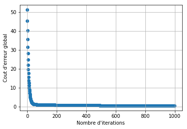

```python
xx = []; yy =[]
# dessiner l’avancer des differents de J(theta0 , theta1)
for i in range(len(COST_RECORDER)):
    xx. append(i)
    yy. append(COST_RECORDER[i])
axes = plt.axes()
axes.grid ()
plt.xlabel ('Nombre d\'iterations')
plt.ylabel ('Cout d\'erreur global')
plt.scatter (xx ,yy)
plt.show()
```

## Exercice 2: Selection de modèles

On considère le jeu de données suivant

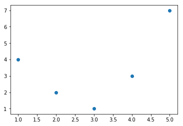

```python
# importation des modules
# generation des données
x = np.array([1 , 2 , 3 , 4 , 5])
y = np.array([4 , 2 , 1 , 3 , 7])
plt.scatter (x, y);
```

### 1. Tester et interpréter le script qui suit

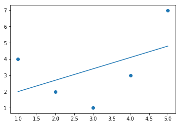

```python
from sklearn . linear_model import LinearRegression
X = x[:, np.newaxis]
model = LinearRegression().fit(X, y)
yfit = model.predict(X)
plt.scatter(x, y)
plt.plot(x, yfit);
```

**Interprétation:**

```python
# Calcul du Mean Squared Error
from sklearn.metrics import mean_squared_error
print("Mean absolute error: %.2f" % mean_squared_error(yfit, y))
```

```
Mean absolute error: 3.26
```

La valeur du coût MSE assez élevée pour considérer le modèle comme assez prédictif. On a un sous-apprentissage dans ces conditions, l'idée serait de modifier le modèle en ajoutant plus de parametres de manière à minimiser le coût.

### 2. Afin d’améliorer le résultat, un modèle polynomial de degré 3 est utilisé.

```
[[  1.   1.   1.]
 [  2.   4.   8.]
 [  3.   9.  27.]
 [  4.  16.  64.]
 [  5.  25. 125.]]
```

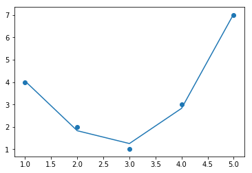

```python
# Modèle polynomial
from sklearn . preprocessing import PolynomialFeatures
poly = PolynomialFeatures(degree =3, include_bias=False)
X2 = poly.fit_transform(X)
print (X2)
model = LinearRegression().fit(X2 , y)
yfit = model.predict(X2)
plt.scatter(x, y)
plt.plot(x, yfit);
```

#### a. Dans le script qui suit, que représente X2 ?

X2 est une nouvelle matrice d'entités constituée de toutes les combinaisons polynomiales des caractéristiques avec un degré inférieur ou égal au degré spécifié (i.e une colonne représentant x, une deuxième colonne représentant x^2 et une troisième colonne représentant x^3).

#### b. Est ce que le modèle polynomial est meilleur que le modèle linéaire de la question précédente ?

```python
# Calcul du Mean Squared Error
from sklearn.metrics import mean_squared_error
print("Mean absolute error: %.2f" % mean_squared_error(yfit, y))
```

```
Mean absolute error: 0.03
```

On constate une valeur du cout MSE bien plus petite 0.03 que celle obtenue avec le modèle précédent 3.26 ce qui permet de dire de le modèle polynomial est bien meilleur.

#### c. Comparez les résultats obtenus lorsque l’on utilise un polynome de degré 2, 3, 4, 5.

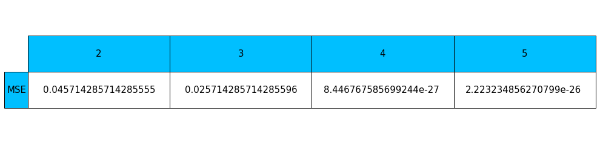

```python
# commencons par definir une liste de valeur
degrees = [2,3,4,5]
values = [["" for c in range(len(degrees))]]
for value in degrees:
    # Modèle polynomial
    from sklearn . preprocessing import PolynomialFeatures
    poly = PolynomialFeatures(degree = value, include_bias=False)
    X2 = poly.fit_transform(X)
    model = LinearRegression().fit(X2 , y)
    yfit = model.predict(X2)
    values[0][value - 2] = mean_squared_error(yfit, y)

fig = plt.figure()
ax = fig.add_subplot(111)
ax.set_axis_off()

# Draw table
the_table = plt.table(
    cellText = values,
    rowLabels = ['MSE'],
    colLabels = degrees,
    colWidths=[0.7] * len(degrees),
    rowColours =["deepskyblue"],
    colColours =["deepskyblue"] * len(degrees),
    loc='center')
the_table.auto_set_font_size(False)
the_table.set_fontsize(15)
the_table.scale(1, 5)
```

On constate le coût du MSE qui decroît au fur et à mesure que le degré augmente. Ainsi le modèle a une très bonne accuracy à partir du degré = 4 où ça atteint un minimum.

### 3. Maintenant nous souhaitons sélectionner le meilleur modèle polynomial.

#### a. Interpréter le segment de code qui suit

```python
from sklearn.preprocessing import PolynomialFeatures
from sklearn.linear_model import LinearRegression
from sklearn.pipeline import make_pipeline

def PolynomialRegression(degree=2, **kwargs):
    return make_pipeline(PolynomialFeatures(degree), LinearRegression(**kwargs))
```

Le but du pipeline consiste à définir chaque type de transformateur afin de faciliter la mise en œuvre et l'ordre des étapes de la construction du modèle. La fonction PolynomialRegression applique cette transformation en deux etapes:

1. D'abord la creation d'un transformateur numérique: PolynomialFeatures
2. Enfin un pipeline qui combine cela avec le model sklearn: LinearRegression

#### b. Pour la suite, nous considérons le jeu de données générées par la fonction qui suit

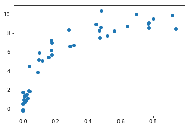

```python
def make_data (N, err=1.0 , rseed=1):
    # randomly sample the data
    rng = np.random.RandomState(rseed)
    X = rng.rand(N, 1) ** 2
    y = 10 - 1./(X.ravel()+0.1)
    if err > 0:
        y += err * rng.randn(N)
    return X, y

X, y = make_data(40)
plt.figure()
plt.scatter(X, y)
```

#### c. Comparez les modèles polynomiales (degree 1, 3, 5) en vous inspirant du script qui suit

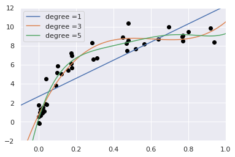

```python
import seaborn; seaborn.set()
X_test = np.linspace(-0.1, 1.1, 500)[:, None]
plt.figure()
plt.scatter(X.ravel(), y, color ='black')
axis = plt.axis()
for degree in [1, 3, 5]:
    y_test = PolynomialRegression(degree).fit(X, y).predict(X_test)
    plt.plot(X_test.ravel(), y_test, label ='degree ={0}'.format(degree))
plt.xlim(-0.1, 1.0)
plt.ylim (-2, 12)
plt.legend(loc='best');
```

À mesure que nous augmentons la complexité du modèle (en augmentant le degré de caractéristiques polynomiales), nous passons d'abord d'un mauvais modèle (degré 1), qui a un biais élevé (sous-ajustement), à un bon modèle (degré 3), puis à un autre mauvais modèle (degré 5), qui a une variance élevée (sur-ajustement). Nous devons donc nous assurer que l’augmentation de la complexité ne nuit pas à nos performances.

#### d. A l’aide des courbes de validation, étudier les degres en fonction du score.

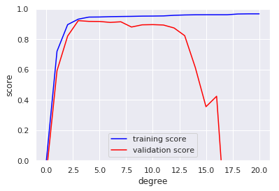

```python
from sklearn.model_selection import validation_curve
degree = np.arange(0, 21)
train_score , val_score = validation_curve(PolynomialRegression(), X, y, 'polynomialfeatures__degree', degree, cv =7)
plt.figure()
plt.plot(degree, np.median(train_score, 1), color ='blue', label ='training score')
plt.plot(degree, np.median(val_score, 1) , color ='red', label ='validation score')
plt.legend(loc ='best')
plt.ylim (0, 1)
plt.xlabel('degree')
plt.ylabel('score');
```

À partir de la courbe de validation, nous pouvons lire que le score d'entraînement est partout supérieur au score de validation. De plus le score d'entraînement s'améliore de façon monotone avec une complexité accrue du modèle (variation du degré). Cependant le score de validation atteint un maximum (au environ de degré = 3) avant de chuter lorsque le modèle devient surajuster.

#### e. Interpréter le segment de code qui suit

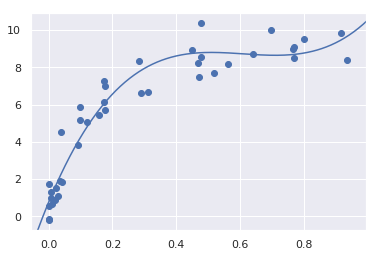

```python
plt.figure()
plt.scatter(X.ravel(), y)
lim = plt.axis()
y_test = PolynomialRegression(3).fit(X, y).predict(X_test)
plt.plot(X_test.ravel(), y_test);
plt.axis(lim);
```

Ceci montre précisément le comportement qualitatif attendu: le compromis optimal entre le biais et la variance est trouvé pour un polynôme du troisième ordre.

#### f. Interpréter le segment de code qui suit

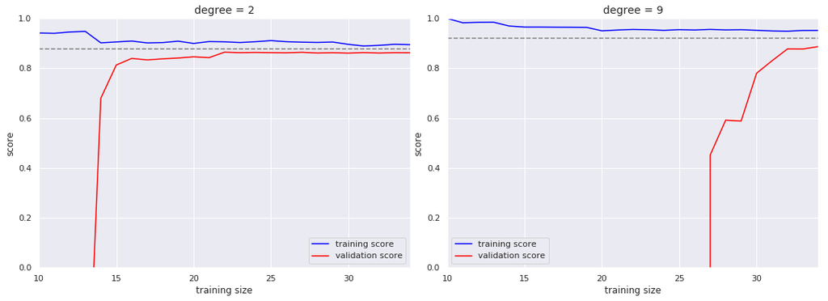

```python
from sklearn.model_selection import learning_curve
plt.figure()
fig, ax = plt.subplots(1, 2, figsize =(16 , 6))
fig.subplots_adjust(left =0.0625, right =0.95, wspace =0.1)
for i, degree in enumerate ([2 , 9]):
    N, train_lc , val_lc = learning_curve (PolynomialRegression(degree), X, y, cv =7,
                                           train_sizes =np. linspace (0.3 , 1 , 25))
    ax[i].plot(N, np.mean(train_lc, 1), color ='blue', label ='training score')
    ax[i].plot(N, np.mean(val_lc, 1), color ='red', label ='validation score')
    ax[i].hlines(np.mean([train_lc[-1], val_lc[-1]]), N[0], N[-1] , color ='gray', linestyle ='dashed')
    ax[i].set_ylim(0, 1)
    ax[i].set_xlim(N[0] , N[-1])
    ax[i].set_xlabel('training size')
    ax[i].set_ylabel('score')
    ax[i].set_title('degree = {0}'.format(degree), size =14)
    ax[i].legend(loc ='best')
```

Il s'agit d'un diagnostic précieux, car il nous donne une représentation visuelle de la façon dont notre modèle répond à l'augmentation des données d'entraînement. En particulier, lorsque la courbe d'apprentissage a déjà convergé (c'est-à-dire lorsque les courbes d'entraînement et de validation sont déjà proches l'une de l'autre), l'ajout de données d'entraînement supplémentaires n'améliorera pas considérablement l'ajustement! Cette situation est visible dans le panneau de gauche, avec la courbe d'apprentissage pour le modèle de degré 2.

La seule façon d'augmenter le score convergé est d'utiliser un modèle différent (généralement plus compliqué). On le voit dans le panneau de droite: en passant à un modèle beaucoup plus compliqué, on augmente le score de convergence (indiqué par la ligne en pointillés), mais au détriment d'une variance plus élevée du modèle (indiquée par la différence entre les scores d'apprentissage et de validation). Si nous devions ajouter encore plus de points de données, la courbe d'apprentissage pour le modèle plus compliqué finirait par converger.

Le tracé d'une courbe d'apprentissage (learning_curves) pour le choix particulier de modèle et de jeu de données peut ainsi aider à prendre ce type de décision sur la manière d'avancer dans l'amélioration du modèle.

## Exercice 3: Classement : régression logistique

### 1. Charger le jeu de données.

```python
from sklearn import datasets
# Scatter plot
iris = datasets.load_iris()
#Utiliser les deux premiers colonnes afin d'avoir un probleme de classification binaire
X = iris["data"][:,3:]  # petal width
y = (iris["target"]==2).astype(np.int)
```

### 2. Entrainer le modèle de régression logistic.

```python
from sklearn.model_selection import train_test_split
X_train, X_test, y_train, y_test = train_test_split( X, y, test_size=0.2, random_state=4)
print ('Train set:', X_train.shape,  y_train.shape)
print ('Test set:', X_test.shape,  y_test.shape)
```

```
Train set: (120, 1) (120,)
Test set: (30, 1) (30,)
```

```python
from sklearn.linear_model import LogisticRegression
log_reg = LogisticRegression(penalty="l2")
log_reg.fit(X_train,y_train)
```

```
LogisticRegression(C=1.0, class_weight=None, dual=False, fit_intercept=True,
          intercept_scaling=1, max_iter=100, multi_class='warn',
          n_jobs=None, penalty='l2', random_state=None, solver='warn',
          tol=0.0001, verbose=0, warm_start=False)
```

### 3. Générer les probabilités estimés par le modèle.

```python
X_new = np.linspace(0,3,1000).reshape(-1,1)
y_proba = log_reg.predict_proba(X_new)
```

### 4. Dans une même figure les courbes d’évolutions correspondante.

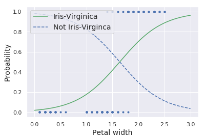

```python
plt.plot(X,y,"b.")
plt.plot(X_new,y_proba[:,1],"g-",label="Iris-Virginica")
plt.plot(X_new,y_proba[:,0],"b--",label="Not Iris-Virginca")
plt.xlabel("Petal width", fontsize=14)
plt.ylabel("Probability", fontsize=14)
plt.legend(loc="upper left", fontsize=14)
plt.show()
```

### 5. Interpéter les graphes et discuter sur la frontière de décision.

En se basant sur le graphe, on peut constater que la probabilité pour qu'une fleur soit de type Virginica reste élevée lorsque la largeur des pétales dépasse les 1.6 cm. Dans le cas contraire, la probabilité reste faible.

### 6. Calculer la précision du modèle.

```python
from sklearn.metrics import log_loss
y_prob = log_reg.predict_proba(X_test)
print ("LogLoss: : %.2f" % log_loss(y_test, y_prob))
```

```
LogLoss: : 0.23
```

### 7. Régression logsitique multinomiale..

#### a. Utiliser la régression softmax pour répartir les fleur d’iris en trois classes.

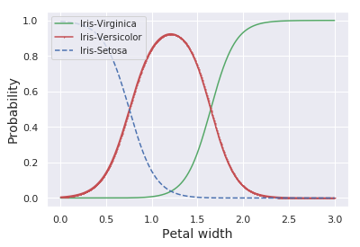

```python
X = iris["data"][:,3:]  # petal width
y = iris["target"]

softmax_reg = LogisticRegression(multi_class="multinomial", solver="lbfgs", C=5)
softmax_reg.fit(X,y)

X_new = np.linspace(0,3,1000).reshape(-1,1)
y_proba = softmax_reg.predict_proba(X_new)


plt.plot(X_new,y_proba[:,2],"g-",label="Iris-Virginica")
plt.plot(X_new,y_proba[:,1],"r+-", markersize=1,label="Iris-Versicolor")
plt.plot(X_new,y_proba[:,0],"b--",label="Iris-Setosa")
plt.xlabel("Petal width", fontsize=14)
plt.ylabel("Probability", fontsize=14)
plt.legend(loc="upper left", fontsize=10)
plt.show()
```

#### c. Implémenter une descente de gradient ordinaire avec arrêt précoce avec une régression softmax sans utiliser Scikit-Learn.

Commençons par écrire une fonction pour calculer les φi. Il prend dans la matrice de paramètres θ, et un vecteur de caractéristiques x.

```python
import math
def phi(i,theta,x):  #i qui va de 1 à k
    mat_theta = np.matrix(theta[i])
    mat_x = np.matrix(x)
    num = math.exp(np.dot(mat_theta,mat_x.T))
    den = 0
    for j in range(0,k):
        mat_theta_j = np.matrix(theta[j])
        den = den + math.exp(np.dot(mat_theta_j,mat_x.T))
    phi_i = num/den
    return phi_i

#Ensuite, nous implémentons l'indicateur
def indicator(a,b):
    if a == b: return 1
    else: return 0
```

Lors de la recherche de nos paramètres, nous utilisons la fonction de descente de gradient. Nous calculons la dérivée du gradient à chaque itération. Nous implémentons donc les deux fonctions, l'une pour calculer la dérivée du gradient et l'autre pour exécuter la méthode de descente de gradient. Nous donnons les valeurs par défaut pour le paramètre d'apprentissage alpha et le nombre d'itérations. Ici, m est le nombre d'exemples d'entraînement dans notre jeu de données.

```python
def get__der_grad(j,theta):
    sum = np.array([0 for i in range(0,n+1)])
    for i in range(0,m):
        p = indicator(y[i],j) - phi(j,theta,x.loc[i])
        sum = sum + (x.loc[i] *p)
    grad = -sum/m
    return grad
```

```python
def gradient_descent(theta,alpha= 1/(10^4),iters=500):
    for j in range(0,k):
        for iter in range(iters):
            theta[j] = theta[j] - alpha * get__der_grad(j,theta)
    print('running iterations')
    return theta
```

Enfin, nous définissons notre fonction d'hypothèse qui nous donnera la probabilité d'obtenir chaque résultat étant donné un vecteur de caractéristiques x.

```python
def h_theta(x):
    x = np.matrix(x)
    h_matrix = np.empty((k,1))
    den = 0
    for j in range(0,k):
        den = den + math.exp(np.dot(theta_dash[j], x.T))
    for i in range(0,k):
        h_matrix[i] = math.exp(np.dot(theta_dash[i],x.T))
    h_matrix = h_matrix/den
    return h_matrix
```

Comme toutes les fonctions sont maintenant définies, il est temps de lire le jeu de données.

```python
import seaborn as sns
iris = sns.load_dataset('iris')
print(iris.head())

train, test = train_test_split(iris, test_size = 0.3)# ici nos données principales sont divisées en train et test
train = train.reset_index()
test = test.reset_index()
```

```
   sepal_length  sepal_width  petal_length  petal_width species
0           5.1          3.5           1.4          0.2  setosa
1           4.9          3.0           1.4          0.2  setosa
2           4.7          3.2           1.3          0.2  setosa
3           4.6          3.1           1.5          0.2  setosa
4           5.0          3.6           1.4          0.2  setosa
```

Nous attribuons la partie fonctionnalités de notre ensemble de données d'entraînement à x. Ensuite, nous définissons n comme le nombre d'attributs ou de fonctionnalités et m comme le nombre d'exemples d'entraînement.

```python
x = train[['sepal_length', 'sepal_width', 'petal_length', 'petal_width']]
n = x.shape[1]
m = x.shape[0]
```

Le résultat ou la partie «Espèce» dans nos données de formation est attribué à y et les différentes classes de fleurs sont remplacées par des valeurs numériques 0,1 et 2. k est le nombre de résultats possibles pour y.

```python
y = train['species']
k = len(y.unique())
y = y.map({'setosa':0,'versicolor':1,'virginica':2})
y.value_counts()
```

```
1    36
0    35
2    34
Name: species, dtype: int64
```

Nous ajoutons une colonne à x qui n'a que des 1 pour signifier la partie d'interception des lignes qui serait ajustée pour notre modèle

```python
x[5] = np.ones(x.shape[0])
x.shape
```

```
(105, 5)
```

On initialise thêta comme une matrice vide (k X n + 1)

```python
theta = np.empty((k,n+1))
```

Tout est fait et nous pouvons commencer à entraîner notre algorithme. Pour trouver des paramètres, nous appliquons la fonction descente de gradient sur notre matrice vide theta et affectons la matrice de paramètres obtenue à theta_dash.

```python
theta_dash = gradient_descent(theta)
theta_dash #Nous obtenons ici les paramètres de notre modèle
```

```
running iterations
```

```
array([[ 0.53266564,  1.43155401, -2.21328585, -0.99859241,  0.29526345],
       [ 0.6361451 , -0.13080784, -0.43772344, -1.16458006,  0.34015254],
       [-0.85650782, -0.91924709,  1.30953461,  1.14628887, -0.48876386]])
```

Maintenant, appliquons notre modèle à notre ensemble de test et obtenons notre précision.

```python
x_u = test[['sepal_length', 'sepal_width', 'petal_length', 'petal_width']]
n = x_u.shape[1]
m = x_u.shape[0]
```

y_true sont les vrais résultats dans notre ensemble de tests. Modifions-les comme nous l'avons fait avec l'ensemble d'apprentissage et attribuons-lui des valeurs numériques.

```python
y_true = test['species']
k = len(y_true.unique())
y_true =y_true.map({'setosa':0,'versicolor':1,'virginica':2})
y_true.value_counts()
```

```
2    16
0    15
1    14
Name: species, dtype: int64
```

Encore une fois, comme nous l'avons fait pendant l'entraînement, nous ajoutons une colonne de one à x_u.

```python
x_u[5] = np.ones(x_u.shape[0])
x_u.shape
```

```
(45, 5)
```

Nous appliquons l'algorithme à chaque ligne de notre ensemble de tests ou x_u en utilisant notre fonction d'hypothèse et trouvons la valeur maximale des probabilités obtenues et son indice correspondant dans la matrice de probabilité obtenue. L'index de la valeur maximale est notre valeur prédite pour cette ligne particulière dans notre ensemble de test.

```python
for index,row in x_u.iterrows():
    h_matrix = h_theta(row)
    prediction = int(np.where(h_matrix == h_matrix.max())[0])
    x_u.loc[index,'prediction'] = prediction
```

Nous pouvons maintenant attribuer nos valeurs prédites, les valeurs réelles et les fonctionnalités de notre ensemble de test à une trame de données qu'on va appeler results.

```python
results = x_u
results['actual'] = y_true
```

```python
results.head(10)
```

|  | sepal_length | sepal_width | petal_length | petal_width | 5 | prediction | actual |
| --- | --- | --- | --- | --- | --- | --- | --- |
| 0 | 6.1 | 2.6 | 5.6 | 1.4 | 1.0 | 2.0 | 2 |
| 1 | 5.4 | 3.0 | 4.5 | 1.5 | 1.0 | 2.0 | 1 |
| 2 | 5.0 | 2.3 | 3.3 | 1.0 | 1.0 | 1.0 | 1 |
| 3 | 5.7 | 3.0 | 4.2 | 1.2 | 1.0 | 1.0 | 1 |
| 4 | 5.0 | 3.6 | 1.4 | 0.2 | 1.0 | 0.0 | 0 |
| 5 | 6.8 | 3.0 | 5.5 | 2.1 | 1.0 | 2.0 | 2 |
| 6 | 5.4 | 3.4 | 1.5 | 0.4 | 1.0 | 0.0 | 0 |
| 7 | 4.4 | 2.9 | 1.4 | 0.2 | 1.0 | 0.0 | 0 |
| 8 | 5.8 | 2.6 | 4.0 | 1.2 | 1.0 | 1.0 | 1 |
| 9 | 6.9 | 3.1 | 4.9 | 1.5 | 1.0 | 1.0 | 1 |

```python
compare = results['prediction'] == results['actual']
correct = compare.value_counts()[1]
accuracy = correct/len(results)
accuracy
```

```
0.9777777777777777
```

Dans les quelques lignes précédentes, nous pouvons voir que notre précision est incroyable 97.77%.

## Exercice 4: Classification

### 1. Jeu de donnée MNIST.

#### a. Concevez un classificateur pour le jeu de données MNIST.

```python
%%time
from sklearn.datasets import fetch_openml
mnist = fetch_openml(data_id=554) # https://www.openml.org/d/554
```

```
CPU times: user 24.3 s, sys: 892 ms, total: 25.1 s
Wall time: 28.9 s
```

```python
type(mnist.data), type(mnist.categories), type(mnist.feature_names), type(mnist.target)
```

```
(numpy.ndarray, dict, list, numpy.ndarray)
```

```python
mnist.data.shape, mnist.target.shape
```

```
((70000, 784), (70000,))
```

Il y a 70 000 images, chacune de dimension 28x28 pixels.

**Aperçu de quelques images**

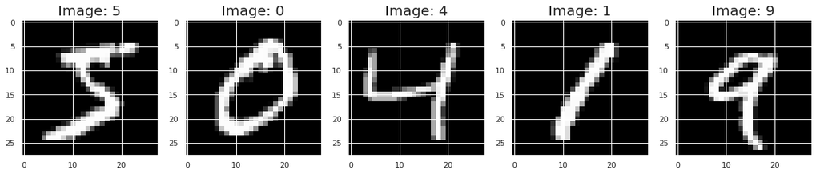

```python
plt.figure(figsize=(20,4))
for index, (image, label) in enumerate(zip(mnist.data[0:5], mnist.target[0:5])):
    plt.subplot(1, 5, index + 1)
    plt.imshow(np.reshape(image, (28,28)), cmap=plt.cm.gray)
    plt.title('Image: ' + label, fontsize = 20);
```

**Split into training and test**

```python
X, y = mnist["data"], mnist["target"]
```

```python
X_train, X_test, y_train, y_test = X[:60000], X[60000:], y[:60000], y[60000:]
```

```python
import numpy as np
shuffle_index = np.random.permutation(60000)
X_train, y_train = X_train[shuffle_index], y_train[shuffle_index]
```

**Entrainement**

```python
from sklearn.linear_model import LogisticRegression
clf = LogisticRegression(fit_intercept=True,
                        multi_class='auto',
                        penalty='l1', #lasso regression
                        solver='saga',
                        max_iter=1000,
                        C=50,
                        verbose=2, # output progress
                        n_jobs=5, # parallelize over 5 processes
                        tol=0.01
                         )
clf
```

```
LogisticRegression(C=50, class_weight=None, dual=False, fit_intercept=True,
          intercept_scaling=1, max_iter=1000, multi_class='auto', n_jobs=5,
          penalty='l1', random_state=None, solver='saga', tol=0.01,
          verbose=2, warm_start=False)
```

```python
%%time
clf.fit(X_train, y_train)
```

```
[Parallel(n_jobs=5)]: Using backend ThreadingBackend with 5 concurrent workers.
```

```
convergence after 45 epochs took 392 seconds
CPU times: user 6min 31s, sys: 92 ms, total: 6min 31s
Wall time: 6min 31s
```

```
[Parallel(n_jobs=5)]: Done   1 out of   1 | elapsed:  6.5min finished
```

```
LogisticRegression(C=50, class_weight=None, dual=False, fit_intercept=True,
          intercept_scaling=1, max_iter=1000, multi_class='auto', n_jobs=5,
          penalty='l1', random_state=None, solver='saga', tol=0.01,
          verbose=2, warm_start=False)
```

**Voyons ce que le classificateur a appris**

```python
clf.classes_
```

```
array(['0', '1', '2', '3', '4', '5', '6', '7', '8', '9'], dtype=object)
```

```python
clf.coef_
```

```
array([[0., 0., 0., ..., 0., 0., 0.],
       [0., 0., 0., ..., 0., 0., 0.],
       [0., 0., 0., ..., 0., 0., 0.],
       ...,
       [0., 0., 0., ..., 0., 0., 0.],
       [0., 0., 0., ..., 0., 0., 0.],
       [0., 0., 0., ..., 0., 0., 0.]])
```

```python
clf.intercept_
```

```
array([-1.17385906e-04,  1.34412986e-04,  1.23782026e-04, -1.97942040e-04,
        6.05982645e-05,  7.84500244e-04, -6.30007203e-05,  2.43397854e-04,
       -7.82010116e-04, -1.86352595e-04])
```

**Score**

```python
from sklearn.metrics import log_loss
score = clf.score(X_test, y_test)
y_prob = clf.predict_proba(X_test)
print ("LogLoss: : %.2f" % log_loss(y_test, y_prob))
print ("score: : %.2f" % score)
```

```
LogLoss: : 0.28
score: : 0.93
```

#### b. Ecrivez une fonction qui peut décaler une image MNIST d’un pixel dans une direction quelconque.

```python
from scipy.ndimage.interpolation import shift
```

```python
def shift_image(image, dx, dy):
    image = image.reshape((28, 28))
    shifted_image = shift(image, [dy, dx], cval=0, mode="constant")
    return shifted_image.reshape([-1])
```

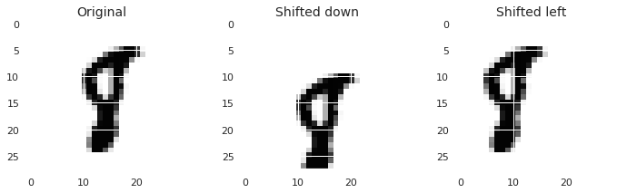

```python
image = X_train[1000]
shifted_image_down = shift_image(image, 0, 5)
shifted_image_left = shift_image(image, -5, 0)

plt.figure(figsize=(12,3))
plt.subplot(131)
plt.title("Original", fontsize=14)
plt.imshow(image.reshape(28, 28), interpolation="nearest", cmap="Greys")
plt.subplot(132)
plt.title("Shifted down", fontsize=14)
plt.imshow(shifted_image_down.reshape(28, 28), interpolation="nearest", cmap="Greys")
plt.subplot(133)
plt.title("Shifted left", fontsize=14)
plt.imshow(shifted_image_left.reshape(28, 28), interpolation="nearest", cmap="Greys")
plt.show()
```

#### c. Puis, pour chaque image du jeu d’entraînement, créez quatre copies décalées et ajoutez les au jeu d’entraînement.

```python
X_train_augmented = [image for image in X_train]
y_train_augmented = [label for label in y_train]

for dx, dy in ((1, 0), (-1, 0), (0, 1), (0, -1)):
    for image, label in zip(X_train, y_train):
        X_train_augmented.append(shift_image(image, dx, dy))
        y_train_augmented.append(label)

X_train_augmented = np.array(X_train_augmented)
y_train_augmented = np.array(y_train_augmented)
```

```python
shuffle_idx = np.random.permutation(len(X_train_augmented))
X_train_augmented = X_train_augmented[shuffle_idx]
y_train_augmented = y_train_augmented[shuffle_idx]
```

#### d. Ensuite entraînez votre meilleur modèle sur ce jeu d’entraînement étendu et mesurez son excatitude sur le jeu de test.

```python
clf.fit(X_train_augmented, y_train_augmented)
```

```
[Parallel(n_jobs=5)]: Using backend ThreadingBackend with 5 concurrent workers.
```

```
convergence after 48 epochs took 2132 seconds
```

```
[Parallel(n_jobs=5)]: Done   1 out of   1 | elapsed: 35.5min finished
```

```
LogisticRegression(C=50, class_weight=None, dual=False, fit_intercept=True,
          intercept_scaling=1, max_iter=1000, multi_class='auto', n_jobs=5,
          penalty='l1', random_state=None, solver='saga', tol=0.01,
          verbose=2, warm_start=False)
```

```python
score = clf.score(X_test, y_test)
print ("score: : %.2f" % score)
```

```
score: : 0.93
```

#### e. Construire un classificateur de spam.

**i. Récupérez les exemples de spam et de ham dans les jeu de données publics Spam Assassin d’Apache.**

```python
import os
import tarfile
from six.moves import urllib

DOWNLOAD_ROOT = "http://spamassassin.apache.org/old/publiccorpus/"
HAM_URL = DOWNLOAD_ROOT + "20030228_easy_ham.tar.bz2"
SPAM_URL = DOWNLOAD_ROOT + "20030228_spam.tar.bz2"
SPAM_PATH = os.path.join("datasets", "spam")

def fetch_spam_data(spam_url=SPAM_URL, spam_path=SPAM_PATH):
    if not os.path.isdir(spam_path):
        os.makedirs(spam_path)
    for filename, url in (("ham.tar.bz2", HAM_URL), ("spam.tar.bz2", SPAM_URL)):
        path = os.path.join(spam_path, filename)
        if not os.path.isfile(path):
            urllib.request.urlretrieve(url, path)
        tar_bz2_file = tarfile.open(path)
        tar_bz2_file.extractall(path=SPAM_PATH)
        tar_bz2_file.close()
```

```python
fetch_spam_data()
```

**ii. Dézippez ces jeux de données et familiarisez-vous avec leur format.**

Chargeons tous les e-mails:

```python
HAM_DIR = os.path.join(SPAM_PATH, "easy_ham")
SPAM_DIR = os.path.join(SPAM_PATH, "spam")
ham_filenames = [name for name in sorted(os.listdir(HAM_DIR)) if len(name) > 20]
spam_filenames = [name for name in sorted(os.listdir(SPAM_DIR)) if len(name) > 20]
```

```python
len(ham_filenames)
```

```
2500
```

```python
len(spam_filenames)
```

```
500
```

```python
import email
import email.policy

def load_email(is_spam, filename, spam_path=SPAM_PATH):
    directory = "spam" if is_spam else "easy_ham"
    with open(os.path.join(spam_path, directory, filename), "rb") as f:
        return email.parser.BytesParser(policy=email.policy.default).parse(f)
```

```python
ham_emails = [load_email(is_spam=False, filename=name) for name in ham_filenames]
spam_emails = [load_email(is_spam=True, filename=name) for name in spam_filenames]
```

Regardons un exemple de spam et un exemple qui l'est pas, pour avoir une idée de ce à quoi ressemblent les données:

```python
print(ham_emails[1].get_content().strip())
```

```
Martin A posted:
Tassos Papadopoulos, the Greek sculptor behind the plan, judged that the
 limestone of Mount Kerdylio, 70 miles east of Salonika and not far from the
 Mount Athos monastic community, was ideal for the patriotic sculpture.

 As well as Alexander's granite features, 240 ft high and 170 ft wide, a
 museum, a restored amphitheatre and car park for admiring crowds are
planned
---------------------
So is this mountain limestone or granite?
If it's limestone, it'll weather pretty fast.

------------------------ Yahoo! Groups Sponsor ---------------------~-->
4 DVDs Free +s&p Join Now
http://us.click.yahoo.com/pt6YBB/NXiEAA/mG3HAA/7gSolB/TM
---------------------------------------------------------------------~->

To unsubscribe from this group, send an email to:
forteana-unsubscribe@egroups.com



Your use of Yahoo! Groups is subject to http://docs.yahoo.com/info/terms/
```

```python
print(spam_emails[6].get_content().strip())
```

```
Help wanted.  We are a 14 year old fortune 500 company, that is
growing at a tremendous rate.  We are looking for individuals who
want to work from home.

This is an opportunity to make an excellent income.  No experience
is required.  We will train you.

So if you are looking to be employed from home with a career that has
vast opportunities, then go:

http://www.basetel.com/wealthnow

We are looking for energetic and self motivated people.  If that is you
than click on the link and fill out the form, and one of our
employement specialist will contact you.

To be removed from our link simple go to:

http://www.basetel.com/remove.html


4139vOLW7-758DoDY1425FRhM1-764SMFc8513fCsLl40
```

Certains e-mails sont en fait en plusieurs parties, avec des images et des pièces jointes (qui peuvent avoir leurs propres pièces jointes). Regardons les différents types de structures que nous avons:

```python
def get_email_structure(email):
    if isinstance(email, str):
        return email
    payload = email.get_payload()
    if isinstance(payload, list):
        return "multipart({})".format(", ".join([
            get_email_structure(sub_email)
            for sub_email in payload
        ]))
    else:
        return email.get_content_type()
```

```python
from collections import Counter

def structures_counter(emails):
    structures = Counter()
    for email in emails:
        structure = get_email_structure(email)
        structures[structure] += 1
    return structures
```

```python
structures_counter(ham_emails).most_common()
```

```
[('text/plain', 2408),
 ('multipart(text/plain, application/pgp-signature)', 66),
 ('multipart(text/plain, text/html)', 8),
 ('multipart(text/plain, text/plain)', 4),
 ('multipart(text/plain)', 3),
 ('multipart(text/plain, application/octet-stream)', 2),
 ('multipart(text/plain, text/enriched)', 1),
 ('multipart(text/plain, application/ms-tnef, text/plain)', 1),
 ('multipart(multipart(text/plain, text/plain, text/plain), application/pgp-signature)',
  1),
 ('multipart(text/plain, video/mng)', 1),
 ('multipart(text/plain, multipart(text/plain))', 1),
 ('multipart(text/plain, application/x-pkcs7-signature)', 1),
 ('multipart(text/plain, multipart(text/plain, text/plain), text/rfc822-headers)',
  1),
 ('multipart(text/plain, multipart(text/plain, text/plain), multipart(multipart(text/plain, application/x-pkcs7-signature)))',
  1),
 ('multipart(text/plain, application/x-java-applet)', 1)]
```

```python
structures_counter(spam_emails).most_common()
```

```
[('text/plain', 218),
 ('text/html', 183),
 ('multipart(text/plain, text/html)', 45),
 ('multipart(text/html)', 20),
 ('multipart(text/plain)', 19),
 ('multipart(multipart(text/html))', 5),
 ('multipart(text/plain, image/jpeg)', 3),
 ('multipart(text/html, application/octet-stream)', 2),
 ('multipart(text/plain, application/octet-stream)', 1),
 ('multipart(text/html, text/plain)', 1),
 ('multipart(multipart(text/html), application/octet-stream, image/jpeg)', 1),
 ('multipart(multipart(text/plain, text/html), image/gif)', 1),
 ('multipart/alternative', 1)]
```

Il semble que les e-mails ham sont plus souvent du texte brut, tandis que le spam contient beaucoup de HTML. De plus, de nombreux e-mails ham sont signés à l'aide de PGP, alors qu'aucun spam ne l'est. En bref, il semble que la structure du courrier électronique soit une information utile à avoir.

Jetons maintenant un coup d'œil aux en-têtes des e-mails:

```python
for header, value in spam_emails[0].items():
    print(header,":",value)
```

```
Return-Path : <12a1mailbot1@web.de>
Delivered-To : zzzz@localhost.spamassassin.taint.org
Received : from localhost (localhost [127.0.0.1])	by phobos.labs.spamassassin.taint.org (Postfix) with ESMTP id 136B943C32	for <zzzz@localhost>; Thu, 22 Aug 2002 08:17:21 -0400 (EDT)
Received : from mail.webnote.net [193.120.211.219]	by localhost with POP3 (fetchmail-5.9.0)	for zzzz@localhost (single-drop); Thu, 22 Aug 2002 13:17:21 +0100 (IST)
Received : from dd_it7 ([210.97.77.167])	by webnote.net (8.9.3/8.9.3) with ESMTP id NAA04623	for <zzzz@spamassassin.taint.org>; Thu, 22 Aug 2002 13:09:41 +0100
From : 12a1mailbot1@web.de
Received : from r-smtp.korea.com - 203.122.2.197 by dd_it7  with Microsoft SMTPSVC(5.5.1775.675.6);	 Sat, 24 Aug 2002 09:42:10 +0900
To : dcek1a1@netsgo.com
Subject : Life Insurance - Why Pay More?
Date : Wed, 21 Aug 2002 20:31:57 -1600
MIME-Version : 1.0
Message-ID : <0103c1042001882DD_IT7@dd_it7>
Content-Type : text/html; charset="iso-8859-1"
Content-Transfer-Encoding : quoted-printable
```

**iii. Partagez ces données entre jeu d’entraînement et jeu de test.**

```python
import numpy as np
from sklearn.model_selection import train_test_split

X = np.array(ham_emails + spam_emails)
y = np.array([0] * len(ham_emails) + [1] * len(spam_emails))

X_train, X_test, y_train, y_test = train_test_split(X, y, test_size=0.2, random_state=42)
```

**iv. Ecrivez un pipeline de préparation de données pour convertir chaque e-mail en un vecteur de caractéristiques.**

Bon, commençons à écrire les fonctions de prétraitement. Tout d'abord, nous aurons besoin d'une fonction pour convertir le HTML en texte brut. La fonction suivante supprime d'abord la section 'head', puis convertit toutes les balises 'a' en mot HYPERLINK, puis elle supprime toutes les balises HTML, ne laissant que le texte brut. Pour plus de lisibilité, il remplace également plusieurs sauts de ligne par des sauts de ligne simples, et enfin il déséchappe les entités html (telles que > ou <)

```python
import re
from html import unescape

def html_to_plain_text(html):
    text = re.sub('<head.*?>.*?</head>', '', html, flags=re.M | re.S | re.I)
    text = re.sub('<a\s.*?>', ' HYPERLINK ', text, flags=re.M | re.S | re.I)
    text = re.sub('<.*?>', '', text, flags=re.M | re.S)
    text = re.sub(r'(\s*\n)+', '\n', text, flags=re.M | re.S)
    return unescape(text)
```

Voyons si ça marche. Ceci est du spam HTML:

```python
html_spam_emails = [email for email in X_train[y_train==1] if get_email_structure(email) == "text/html"]
sample_html_spam = html_spam_emails[7]
print(sample_html_spam.get_content().strip()[:1000], "...")
```

```
<HTML><HEAD><TITLE></TITLE><META http-equiv="Content-Type" content="text/html; charset=windows-1252"><STYLE>A:link {TEX-DECORATION: none}A:active {TEXT-DECORATION: none}A:visited {TEXT-DECORATION: none}A:hover {COLOR: #0033ff; TEXT-DECORATION: underline}</STYLE><META content="MSHTML 6.00.2713.1100" …
<BODY text="#000000" vLink="#0033ff" link="#0033ff" bgColor="#CCCC99"><TABLE borderColor="#660000" cellSpacing="0" cellPadding="0" border="0" width="100%"><TR><TD bgColor="#CCCC99" valign="top" colspan="2" height="27">
<font size="6" face="Arial, Helvetica, sans-serif" color="#660000">
<b>OTC</b></font></TD></TR><TR><TD height="2" bgcolor="#6a694f">
<font size="5" face="Times New Roman, Times, serif" color="#FFFFFF">
<b>&nbsp;Newsletter</b></font></TD><TD height="2" bgcolor="#6a694f"><div align="right"><font color="#FFFFFF">
<b>Discover Tomorrow's Winners&nbsp;</b></font></div></TD></TR><TR><TD height="25" colspan="2" bgcolor="#CCCC99"><table width="100%" border="0"  ...
```

Et voici le texte brut résultant:

```python
print(html_to_plain_text(sample_html_spam.get_content())[:1000], "...")
```

```
OTC
 Newsletter
Discover Tomorrow's Winners
For Immediate Release
Cal-Bay (Stock Symbol: CBYI)
Watch for analyst "Strong Buy Recommendations" and several advisory newsletters picking CBYI.  CBYI has filed to be traded on the OTCBB, share prices historically INCREASE when companies get listed on this larger trading exchange. CBYI is trading around 25 cents and should skyrocket to $2.66 - $3.25…
Put CBYI on your watch list, acquire a position TODAY.
REASONS TO INVEST IN CBYI
A profitable company and is on track to beat ALL earnings estimates!
One of the FASTEST growing distributors in environmental & safety equipment instruments.
Excellent management team, several EXCLUSIVE contracts.  IMPRESSIVE client list including the U.S. Air Force, Anheuser-Busch, Chevron Refining and Mitsubishi Heavy Industries, GE-Energy & Environmental Research.
RAPIDLY GROWING INDUSTRY
Industry revenues exceed $900 million, estimates indicate that there could be as much as $25 billi ...
```

Écrivons maintenant une fonction qui prend un e-mail en entrée et renvoie son contenu sous forme de texte brut, quel que soit son format:

```python
def email_to_text(email):
    html = None
    for part in email.walk():
        ctype = part.get_content_type()
        if not ctype in ("text/plain", "text/html"):
            continue
        try:
            content = part.get_content()
        except: # in case of encoding issues
            content = str(part.get_payload())
        if ctype == "text/plain":
            return content
        else:
            html = content
    if html:
        return html_to_plain_text(html)
```

```python
print(email_to_text(sample_html_spam)[:100], "...")
```

```
OTC
 Newsletter
Discover Tomorrow's Winners
For Immediate Release
Cal-Bay (Stock Symbol: CBYI)
Wat ...
```

```python
try:
    import nltk
    stemmer = nltk.PorterStemmer()
    for word in ("Computations", "Computation", "Computing", "Computed", "Compute", "Compulsive"):
        print(word, "=>", stemmer.stem(word))
except ImportError:
    print("Error: stemming requires the NLTK module.")
    stemmer = None
```

```
Computations => comput
Computation => comput
Computing => comput
Computed => comput
Compute => comput
Compulsive => compuls
```

Nous aurons également besoin d'un moyen de remplacer les URL par le mot «URL». Pour cela, nous pourrions utiliser des expressions régulières hardcore mais nous utiliserons ici simplement la bibliothèque urlextract.

```python
try:
    import urlextract
    url_extractor = urlextract.URLExtract()
    print(url_extractor.find_urls("Will it detect github.com and https://youtu.be/7Pq-S557XQU?t=3m32s"))
except ImportError:
    print("Error: replacing URLs requires the urlextract module.")
    url_extractor = None
```

```
Error: replacing URLs requires the urlextract module.
```

Nous sommes prêts à rassembler tout cela dans un transformateur que nous utiliserons pour convertir les e-mails en compteurs de mots. Notez que nous divisons les phrases en mots en utilisant la méthode split () de Python, qui utilise des espaces pour les limites des mots. Cela fonctionne pour de nombreuses langues écrites, mais pas pour toutes. Par exemple, les scripts chinois et japonais n'utilisent généralement pas d'espaces entre les mots, et le vietnamien utilise souvent des espaces même entre les syllabes.

```python
from sklearn.base import BaseEstimator, TransformerMixin

class EmailToWordCounterTransformer(BaseEstimator, TransformerMixin):
    def __init__(self, strip_headers=True, lower_case=True, remove_punctuation=True,
                 replace_urls=True, replace_numbers=True, stemming=True):
        self.strip_headers = strip_headers
        self.lower_case = lower_case
        self.remove_punctuation = remove_punctuation
        self.replace_urls = replace_urls
        self.replace_numbers = replace_numbers
        self.stemming = stemming
    def fit(self, X, y=None):
        return self
    def transform(self, X, y=None):
        X_transformed = []
        for email in X:
            text = email_to_text(email) or ""
            if self.lower_case:
                text = text.lower()
            if self.replace_urls and url_extractor is not None:
                urls = list(set(url_extractor.find_urls(text)))
                urls.sort(key=lambda url: len(url), reverse=True)
                for url in urls:
                    text = text.replace(url, " URL ")
            if self.replace_numbers:
                text = re.sub(r'\d+(?:\.\d*(?:[eE]\d+))?', 'NUMBER', text)
            if self.remove_punctuation:
                text = re.sub(r'\W+', ' ', text, flags=re.M)
            word_counts = Counter(text.split())
            if self.stemming and stemmer is not None:
                stemmed_word_counts = Counter()
                for word, count in word_counts.items():
                    stemmed_word = stemmer.stem(word)
                    stemmed_word_counts[stemmed_word] += count
                word_counts = stemmed_word_counts
            X_transformed.append(word_counts)
        return np.array(X_transformed)
```

Essayons ce transformateur sur quelques emails:

```python
X_few = X_train[:3]
X_few_wordcounts = EmailToWordCounterTransformer().fit_transform(X_few)
X_few_wordcounts
```

```
array([Counter({'chuck': 1, 'murcko': 1, 'wrote': 1, 'stuff': 1, 'yawn': 1, 'r': 1}),
       Counter({'the': 11, 'of': 9, 'and': 8, 'all': 3, 'christian': 3, 'to': 3, 'by': 3, 'jefferson': 2, 'i': 2, 'have': 2, 'superstit': 2, 'one': 2, 'on': 2, 'been': 2, 'ha': 2, 'half': 2, 'rogueri': 2, 'teach': 2, 'jesu': 2, 'some': 1, 'interest': 1, 'quot': 1, 'http': 1, 'www': 1, 'postfun': 1, …
       Counter({'number': 5, 'http': 4, 'yahoo': 4, 's': 3, 'group': 3, 'com': 3, 'to': 3, 'in': 2, 'forteana': 2, 'martin': 2, 'an': 2, 'and': 2, 'memri': 2, 'we': 2, 'is': 2, 'unsubscrib': 2, 'y': 1, 'adamson': 1, 'wrote': 1, 'for': 1, 'altern': 1, 'rather': 1, 'more': 1, 'factual': 1, 'base': 1, …
      dtype=object)
```

Cela semble juste!

Maintenant, nous avons le nombre de mots et nous devons les convertir en vecteurs. Pour cela, nous allons construire un autre transformateur dont la méthode fit () construira le vocabulaire (une liste ordonnée des mots les plus courants) et dont la méthode transform () utilisera le vocabulaire pour convertir le nombre de mots en vecteurs. La sortie est une matrice clairsemée.

```python
from scipy.sparse import csr_matrix

class WordCounterToVectorTransformer(BaseEstimator, TransformerMixin):
    def __init__(self, vocabulary_size=1000):
        self.vocabulary_size = vocabulary_size
    def fit(self, X, y=None):
        total_count = Counter()
        for word_count in X:
            for word, count in word_count.items():
                total_count[word] += min(count, 10)
        most_common = total_count.most_common()[:self.vocabulary_size]
        self.most_common_ = most_common
        self.vocabulary_ = {word: index + 1 for index, (word, count) in enumerate(most_common)}
        return self
    def transform(self, X, y=None):
        rows = []
        cols = []
        data = []
        for row, word_count in enumerate(X):
            for word, count in word_count.items():
                rows.append(row)
                cols.append(self.vocabulary_.get(word, 0))
                data.append(count)
        return csr_matrix((data, (rows, cols)), shape=(len(X), self.vocabulary_size + 1))
```

```python
vocab_transformer = WordCounterToVectorTransformer(vocabulary_size=10)
X_few_vectors = vocab_transformer.fit_transform(X_few_wordcounts)
X_few_vectors
```

```
<3x11 sparse matrix of type '<class 'numpy.int64'>'
	with 20 stored elements in Compressed Sparse Row format>
```

```python
X_few_vectors.toarray()
```

```
array([[  6,   0,   0,   0,   0,   0,   0,   0,   0,   0,   0],
       [112,  11,   9,   8,   3,   1,   0,   1,   3,   0,   1],
       [ 92,   0,   1,   2,   3,   4,   5,   3,   1,   4,   2]],
      dtype=int64)
```

```python
vocab_transformer.vocabulary_
```

```
{'the': 1,
 'of': 2,
 'and': 3,
 'to': 4,
 'http': 5,
 'number': 6,
 'com': 7,
 'all': 8,
 'yahoo': 9,
 'in': 10}
```

Nous sommes maintenant prêts à former notre premier classificateur de spam! Transformons l'ensemble de données:

```python
from sklearn.pipeline import Pipeline

preprocess_pipeline = Pipeline([
    ("email_to_wordcount", EmailToWordCounterTransformer()),
    ("wordcount_to_vector", WordCounterToVectorTransformer()),
])

X_train_transformed = preprocess_pipeline.fit_transform(X_train)
```

**v. Essayez ensuite différents classificateurs et en deduire un bon classifieur de spam, ayant à la fois un rappel et une précision élevée.**

```python
from sklearn.linear_model import LogisticRegression
from sklearn.model_selection import cross_val_score

log_clf = LogisticRegression(solver="liblinear", random_state=42)
score = cross_val_score(log_clf, X_train_transformed, y_train, cv=3, verbose=3)
score.mean()
```

```
[Parallel(n_jobs=1)]: Using backend SequentialBackend with 1 concurrent workers.
[Parallel(n_jobs=1)]: Done   1 out of   1 | elapsed:    0.1s remaining:    0.0s
[Parallel(n_jobs=1)]: Done   2 out of   2 | elapsed:    0.1s remaining:    0.0s
```

```
[CV]  ................................................................
[CV] .................................. , score=0.98375, total=   0.0s
[CV]  ................................................................
[CV] .................................... , score=0.985, total=   0.1s
[CV]  ................................................................
[CV] ................................... , score=0.9925, total=   0.2s
```

```
0.9870833333333334
```

Plus de 98,7%, pas mal pour un premier essai!

Pour la précision / le rappel que nous obtenons sur l'ensemble de test:

```python
from sklearn.metrics import precision_score, recall_score

X_test_transformed = preprocess_pipeline.transform(X_test)

log_clf = LogisticRegression(solver="liblinear", random_state=42)
log_clf.fit(X_train_transformed, y_train)

y_pred = log_clf.predict(X_test_transformed)

print("Precision: {:.2f}%".format(100 * precision_score(y_test, y_pred)))
print("Recall: {:.2f}%".format(100 * recall_score(y_test, y_pred)))
```

```
Precision: 97.89%
Recall: 97.89%
```

# **Papa Omar Diop DIC1 GIT**